# 例三： 实际站点数据

主讲人： 杨金炎  
2022-06-29

下面我们引入一个实际站点的数据。操作本身与之前的测试无异。处理站点实际数据的最主要部分是数据清理。具体方法因实际数据情况而定。此处仅以简单的栗子说明大致研究方法。

此处，需要修改的输入有met、species、thinning以及parameters。其中，尤其以met和parameters最为重要。下面我们依次介绍需要进行的修改。

### 1 气象情况

下面是气象数据随时间的变化。

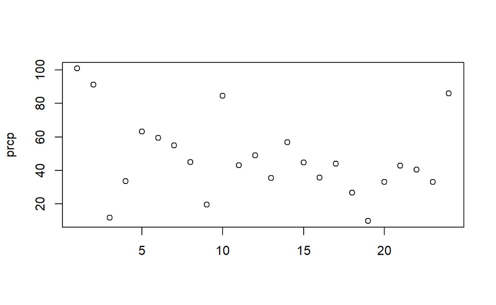

```r
# 读取气象数据
met.df <- read.csv('e:/repo/3pg_lecture/rmd/ros.met.csv')

plot(met.df$prcp,xlab='',ylab = 'prcp')
```

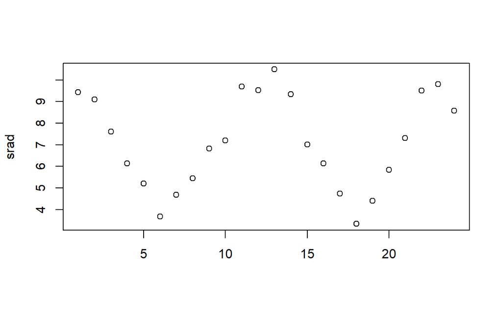

```r
plot(met.df$srad,xlab='',ylab = 'srad')
```

此时，我们依然需要霜冻和二氧化碳信息。

```r
# 霜冻-假定没有
met.df$frost_days <- 0
# 二氧化碳
met.df$co2 <- 400
met.df$srad <- 2.3 * met.df$srad
```

接下来修改站点信息。

```r
site.new <- d_site

site.new$latitude <- -38
site.new$altitude <- 50
site.new$soil_class <- 2
site.new$asw_i <- 150
site.new$asw_min <- 50
site.new$asw_max <- 300
site.new$from <- '2018-01'
site.new$to <- '2019-12'
```

### 2 植物信息

接下来修改植物信息。

```r
spc.new <- d_species[1,]
spc.new$species <- 'ET'
spc.new$planted <- '1900-01'
spc.new$fertility <- 1
spc.new$stems_n <- 400
spc.new$biom_stem <- 90
spc.new$biom_root <- 10
spc.new$biom_foliage <- 0.2
```

### 3 植物参数

现在需要修改参数。对于大多数研究，气象数据和模型参数是最主要的因素。

首先，还是在已有文献中寻找是否有相关参数。

```r
list.spc <- get_parameters(mode = "overview", sp_names = NULL)

e.list <- list.spc$species[grep(pattern = 'Eucalyptus',x = list.spc$species)]

print(e.list)
```

```
 [1] "Eucalyptus globulus"
 [2] "Eucalyptus grandis"
 [3] "Eucalyptus grandis"
 [4] "Eucalyptus grandis"
 [5] "Eucalyptus grandis"
 [6] "Eucalyptus grandis x urophylla"
 [7] "Eucalyptus grandis x urophylla"
 [8] "Eucalyptus grandis x urophylla"
 [9] "Eucalyptus grandis x urophylla"
[10] "Eucalyptus grandis x urophylla"
[11] "Eucalyptus urophylla"
[12] "Eucalyptus grandis x camaldulensis"
[13] "Eucalyptus globulus"
[14] "Eucalyptus nitens"
[15] "Eucalyptus saligna"
[16] "Eucalyptus pelita"
[17] "Eucalyptus cladocalyx"
[18] "Eucalyptus globulus"
[19] "Eucalyptus nitens"
[20] "Eucalyptus nitens"
[21] "Eucalyptus globulus"
[22] "Eucalyptus saligna"
[23] "Eucalyptus grandis x urophylla"
[24] "Eucalyptus grandis x urophylla"
[25] "Eucalyptus grandis"
```

可以看到我们选定的种并不在列。但是，由相似种E.globulus。在此我们就使用E.globulus的参数作为模板。此后只需要修改我们测量得到的参数即可。

```r
et.df <- get_parameters(mode = "full", sp_names = 'Eucalyptus globulus')

et.sub <- subset(et.df[4,],select = -c(source_full,species,
                                       link,notes,parset_id,
                                       source,source_comments,
                                       country,age,type,year,region))
# 修改数据结构
par.new <- d_parameters[,c(1,3)]
names(par.new)[2] <- 'ET'
#
par.new$ET[par.new$parameter == 'SLA0'] <- 50
par.new$ET[par.new$parameter == 'SLA1'] <- 50

par.new$ET[par.new$parameter == 'MaxAge'] <- 500
par.new$ET[par.new$parameter == 'LAImaxIntcptn'] <- 3

par.new$ET[par.new$parameter == 'alphaCx'] <- et.sub$alphaCx
par.new$ET[par.new$parameter == 'fCalpha700'] <- 1.8
par.new$ET[par.new$parameter == 'fCg700'] <- 0.6

par.new$ET[par.new$parameter == 'Tmin'] <- et.sub$Tmin
par.new$ET[par.new$parameter == 'Topt'] <- et.sub$Topt
par.new$ET[par.new$parameter == 'Tmax'] <- et.sub$Tmax

par.new <- par.new[,c('parameter','ET')]
```

### 4 其他参数

最后，需要修改thinning数据。由于实际上我们并不使用自然稀疏的部分。此处我们使用Fagus sylvatica的数据。

```r
#
thin.new <- d_thinning[1,]

thin.new$species <- 'ET'

thin.new$age <- 200
#
size.new <- (d_sizeDist[,1:2])
names(size.new)[2] <- 'ET'
```

修改全部输入数据后，就可以再次运行模型。这一站点的实验内容是增加二氧化碳浓度。因此，我们计算当前二氧化碳和高二氧化碳两种情况。

### 5 实际运行

```r
met.df$co2 <- 400
out.et <- run_3PG(site = site.new,#站点相关信息，初始土壤水
                  species = spc.new,#树种相关信息，初始生物量
                  climate = met.df,#气象因子
                  thinning = thin.new,#间苗
                  parameters = par.new,#按树种的生理参数
                  size_dist = size.new,#修正大小分布
                  settings = list(light_model = 2,
                                  transp_model = 2, phys_model = 2,
                                  correct_bias = 0, calculate_d13c = 0),
                  check_input = TRUE,
                  df_out = TRUE)

#
met.df$co2 <- 550
out.et.eco2 <- run_3PG(site = site.new,#站点相关信息，初始土壤水
                  species = spc.new,#树种相关信息，初始生物量
                  climate = met.df,#气象因子
                  thinning = thin.new,#间苗
                  parameters = par.new,#按树种的生理参数
                  size_dist = size.new,#修正大小分布
                  settings = list(light_model = 2,
                                  transp_model = 2, phys_model = 2,
                                  correct_bias = 0, calculate_d13c = 0),
                  check_input = TRUE,
                  df_out = TRUE)
```

我们可以观察生产力的变化。

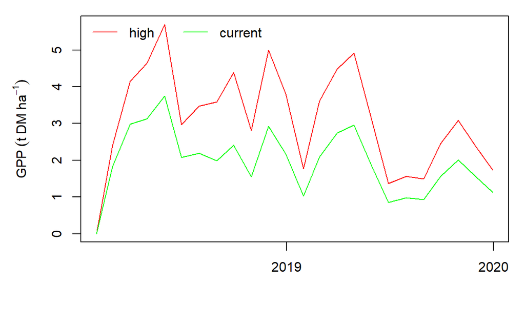

```r
par(mar=c(5,5,1,1))
palette(c(rainbow(3)))
plot(value~date,data = out.et.eco2[out.et.eco2$species == 'ET' &
                                 out.et.eco2$variable == 'gpp',],
       type='l',xlab='',ylab=expression('GPP'~(t~DM~ha^-1)),col=1)

  points(value~date,data = out.et[out.et$species == 'ET' &
                                   out.et$variable == 'gpp',],
         type='l',xlab='',col=2)

  legend('topleft',legend = c('high','current'),
         lty='solid',col=palette(),bty='n',horiz = T)
```

也可以研究蒸腾对二氧化碳浓度的响应。

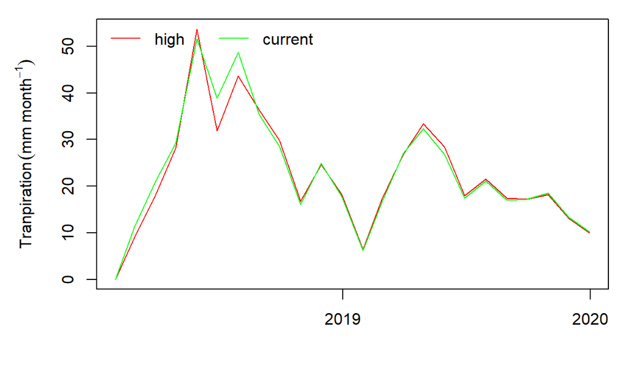

```r
par(mar=c(5,5,1,1))
palette(c(rainbow(3)))
plot(value~date,data = out.et.eco2[out.et.eco2$species == 'ET' &
                                 out.et.eco2$variable == 'transp_veg',],
       type='l',xlab='',
     ylab=expression('Tranpiration'~(mm~month^-1)),col=1)

  points(value~date,data = out.et[out.et$species == 'ET' &
                                   out.et$variable == 'transp_veg',],
         type='l',xlab='',col=2)

  legend('topleft',legend = c('high','current'),
         lty='solid',col=palette(),bty='n',horiz = T)
```